# hw1

```python
import pandas as pd
import math
import numpy as np
import matplotlib.pyplot as plt
from IPython.display import display, HTML, Image
import pygal
from functools import reduce
import collections
from datetime import datetime, timedelta
from hw1 import retrieveData, retrieve2017Data, groupByType, dfByType, galplot
```

## Problem 1: Data Acquisition and Analysis

### 1.1 First thing's first: Import all three CSVs

```python
(alley, graffiti, building) = retrieve2017Data()
assert(not alley.empty)
assert(not graffiti.empty)
assert(not building.empty)
```

### Sub-types

Let's select a couple of columns in each set to use for our sub-type analysis, then group by those columns for summarization:

```python
building_type = "IS BUILDING OPEN OR BOARDED?"
building_subtypes = groupByType(building, building_type)

building_subtypes
```

```
[{'label': 'Boarded', 'value': 688}, {'label': 'Open', 'value': 3140}]
```

```python
alley_type = "Status"
alley_subtypes = groupByType(alley, alley_type)

alley_subtypes
```

```
[{'label': 'Completed', 'value': 14014},
 {'label': 'Completed - Dup', 'value': 13635},
 {'label': 'Open', 'value': 4339},
 {'label': 'Open - Dup', 'value': 2993}]
```

```python
graffiti_type = "What Type of Surface is the Graffiti on?"
graffiti_subtypes = groupByType(graffiti, graffiti_type)

graffiti_subtypes
```

```
[{'label': 'Aluminum Siding', 'value': 3544},
 {'label': 'Asphalt', 'value': 116},
 {'label': 'Brick - Painted', 'value': 17994},
 {'label': 'Brick - Unpainted', 'value': 24359},
 {'label': 'Cement (Sidewalk, Alley, Wall, Curb)', 'value': 12224},
 {'label': 'Glass', 'value': 3371},
 {'label': 'Limestone', 'value': 499},
 {'label': 'Marble/Granite', 'value': 200},
 {'label': 'Metal - Painted', 'value': 54378},
 {'label': 'Metal - Unpainted', 'value': 12096},
 {'label': 'Other / Unknown Surface', 'value': 2400},
 {'label': 'Other/Unknown Surface', 'value': 2636},
 {'label': 'Stucco', 'value': 312},
 {'label': 'Tree', 'value': 167},
 {'label': 'Vinyl Siding', 'value': 1714},
 {'label': 'Wood - Painted', 'value': 5596},
 {'label': 'Wood - Unpainted', 'value': 1971}]
```

### 1.2

Now, let's simply see what the biggest source of calls are, and visualize this data at a very basic level: Questions:

- What is the breakdown of 311 call types among Building Calls, Alley Light Outage Calls, and Graffiti Removal calls? (Nested pie chart)
- In which wards are calls of each type most prevalent? (Stacked bar chart)
- Are calls for a given type of 311 call increasing over time? Decreasing over time? (Summary table)
- How long did each of these calls take to be resolved for each of these cases in 2017? (Stacked bar chart)

Please see below for the output answers to each of these questions

```python
pie_chart = pygal.Pie()
pie_chart.title = '311 Call Types'
pie_chart.add("Building Calls", building_subtypes)
pie_chart.add("Alley Light Calls", alley_subtypes)
pie_chart.add("Graffiti Removal Calls", graffiti_subtypes)
galplot(pie_chart)
```

[interactive chart not shown]

#### Calls by Ward

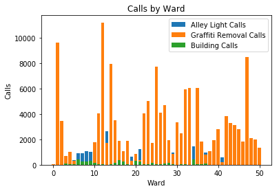

```python
ward_type = "Ward"
ward_alley = dfByType(alley, ward_type)
ward_graffiti = dfByType(graffiti, ward_type)
ward_buildings = dfByType(building, ward_type)

ward_alley

plt.figure(0)
fig, ax = plt.subplots()
ax.bar(ward_alley['Ward'], ward_alley['COUNT'], label="Alley Light Calls")
ax.bar(ward_graffiti['Ward'], ward_graffiti['COUNT'], label="Graffiti Removal Calls")
ax.bar(ward_buildings['Ward'], ward_buildings['COUNT'], label="Building Calls")
plt.xlabel("Ward")
plt.ylabel("Calls")
plt.title("Calls by Ward")
ax.legend()

plt.show()
```

```python
date_alley = dfByType(alley, "Creation Date")
date_alley.set_index(['Creation Date'],inplace=True)
date_alley = date_alley.groupby(pd.Grouper(freq='M'))


date_graffiti = dfByType(graffiti, "Creation Date")
date_graffiti.set_index(['Creation Date'],inplace=True)
date_graffiti = date_graffiti.groupby(pd.Grouper(freq='M'))

date_buildings = dfByType(building, "DATE SERVICE REQUEST WAS RECEIVED")
date_buildings.set_index(["DATE SERVICE REQUEST WAS RECEIVED"],inplace=True)
date_buildings = date_buildings.groupby(pd.Grouper(freq='M'))

print("\nAlley Light calls by Month")
print(date_alley.describe())
print("\nGraffiti calls by Month")
print(date_graffiti.describe())
print("\nBuilding calls by Month")
print(date_buildings.describe())
```

```
Alley Light calls by Month
              COUNT
              count       mean        std   min    25%    50%     75%    max
Creation Date
2017-01-31     31.0  84.064516  39.507751  21.0  51.00   88.0  112.00  157.0
2017-02-28     28.0  91.142857  38.716170  28.0  44.75   99.0  119.25  162.0
2017-03-31     31.0  79.161290  33.365748  19.0  51.00   78.0  107.50  123.0
2017-04-30     30.0  72.966667  30.830441  21.0  48.50   77.0   92.75  129.0
2017-05-31     31.0  73.290323  34.171327  19.0  37.00   74.0   93.50  129.0
2017-06-30     30.0  80.066667  32.624228  24.0  54.00   85.0  101.00  145.0
2017-07-31     31.0  60.225806  29.490913  16.0  28.00   74.0   84.50  116.0
2017-08-31     31.0  65.451613  28.262860  19.0  38.50   70.0   85.00  111.0
2017-09-30     30.0  60.533333  27.041135  16.0  36.00   68.0   79.75  109.0
2017-10-31     31.0  81.419355  39.470474  21.0  42.00   84.0  116.50  139.0
2017-11-30     30.0  94.966667  47.720077  29.0  42.50  104.0  134.00  177.0
2017-12-31     31.0  75.354839  44.353541  10.0  37.00   77.0  115.00  148.0
2018-01-31     31.0  69.451613  32.484703  16.0  39.50   80.0   97.00  124.0
2018-02-28     28.0  73.785714  46.351601   8.0  41.75   67.5  104.75  206.0
2018-03-31     29.0  98.827586  37.617501  29.0  70.00  102.0  115.00  175.0

Graffiti calls by Month
              COUNT                                                       \
              count        mean         std   min     25%    50%     75%
Creation Date
2017-01-31     31.0  291.129032  163.030006  31.0  114.50  309.0  432.00
2017-02-28     28.0  331.500000  187.281626  58.0  103.25  365.5  445.25
2017-03-31     31.0  280.064516  149.658931  41.0  131.00  318.0  382.00
2017-04-30     30.0  290.266667  160.975675  49.0   96.50  351.0  416.75
2017-05-31     31.0  286.161290  180.311785  45.0   97.50  306.0  387.50
2017-06-30     30.0  255.900000  177.094432  53.0  109.75  201.0  399.25
2017-07-31     31.0  230.064516  177.061371  43.0   73.00  155.0  383.50
2017-08-31     31.0  332.129032  188.179479  52.0  160.00  351.0  463.00
2017-09-30     30.0  396.266667  321.472467  49.0   85.25  361.5  562.50
2017-10-31     31.0  350.483871  228.627918  44.0   78.50  396.0  543.00
2017-11-30     30.0  351.933333  206.999073  28.0  120.25  404.0  500.75
2017-12-31     31.0  315.967742  214.710578   3.0   75.50  406.0  486.00
2018-01-31     31.0  344.967742  218.025761  22.0   88.50  407.0  491.50
2018-02-28     28.0  376.321429  248.775379  42.0   90.75  465.0  573.75
2018-03-31     29.0  352.310345  203.347890  50.0  120.00  430.0  489.00

```

[output cut: 42 more lines]

```
2017-01-31                         10.50  19.0
2017-02-28                         19.00  32.0
2017-03-31                         16.75  28.0
2017-04-30                         17.75  27.0
2017-05-31                         19.00  29.0
2017-06-30                         13.00  18.0
2017-07-31                         16.00  21.0
2017-08-31                         14.50  24.0
2017-09-30                         11.75  20.0
2017-10-31                         11.50  18.0
2017-11-30                         11.00  18.0
2017-12-31                          9.00  24.0
2018-01-31                         11.00  18.0
2018-02-28                         10.50  17.0
2018-03-31                         18.00  25.0
```

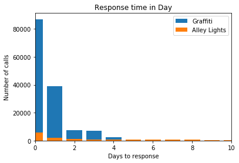

```python
RESOLUTION = "Resolution Time"
graffiti[RESOLUTION] = (graffiti['Completion Date'] - graffiti['Creation Date'])
graffiti_by_resolution = groupByType(graffiti, RESOLUTION)
graffiti_y = []
graffiti_x = []

for point in graffiti_by_resolution:
    graffiti_x.append((point['label'].days))
    graffiti_y.append(point['value'])

alley[RESOLUTION] = (alley['Completion Date'] - alley['Creation Date'])
alley_by_resolution = groupByType(alley, RESOLUTION)
alley_y = []
alley_x = []

for point in alley_by_resolution:
    alley_x.append((point['label'].days))
    alley_y.append(point['value'])


plt.figure(1)
plt.xlim(0, 10)
plt.xlabel("Days to response")
plt.ylabel("Number of calls")
plt.title("Response time in Day")
plt.bar(graffiti_x, graffiti_y, label="Graffiti")
plt.bar(alley_x, alley_y, label="Alley Lights")
plt.legend()
plt.show()
```

Above, we can see that the vast majority of calls take less than a day to respond. In general though, graffiti response times appear to be better than alley-light response times. Response times for buildings were not made possible by this data set.

## Problem 2: Data Augmentation and APIs

1. What types of blocks get “Vacant and Abandoned Buildings Reported”?
   - Group by zip, what is the median income/race, etc.
2. What types of blocks get “Alley Lights Out”?
   - Group by zip, what is the median income/race, etc.
3. Does that change over time in the data you collected?
   - Group by zip, month
4. What is the difference in blocks that get “Vacant and Abandoned Buildings Reported” vs “Alley Lights Out”?
   - Is there a difference in income/race, etc.

```python
from census import Census
from us import states

c = Census("fca63f0c87016d46f9bc5ca3a161d6b85f86f04a")
c.acs5.get(('NAME', 'B25034_010E', 'B02001_002E'), {'for':'state:{}'.format(states.IL.fips)}, year=2016)

# Race fields
RACE_TOTAL = 'B02001_001E'
RACE_WHITE = 'B02001_002E'
RACE_BLACK = 'B02001_003E'

# Citizenship fields
CITIZEN_TOTAL = 'B05001_001E'
CITIZEN_USBORN = 'B05001_002E'
CITIZEN_NATURALIZED = 'B05001_005E'
CITIZEN_NON = 'B05001_006E'

# Income fields
INCOME = 'B19013_001E'
INCOME_WHITE = 'B19013A_001E'
INCOME_BLACK = 'B19013B_001E'
INCOME_SINGLE = 'B19019_002E'
INCOME_2P = 'B19019_003E'
INCOME_3P = 'B19019_004E'
INCOME_4P = 'B19019_005E'
INCOME_5P = 'B19019_006E'
INCOME_6P = 'B19019_007E'
INCOME_7P = 'B19019_008E'

# Tenure by type
TENURE_OWNER = 'B25009_002E'
TENURE_RENTER = 'B25009_010E'

ZIP = 'zip code tabulation area'

FIELDS = (RACE_TOTAL, RACE_WHITE, RACE_BLACK,
          CITIZEN_TOTAL, CITIZEN_USBORN, CITIZEN_NATURALIZED,
         CITIZEN_NON, INCOME, INCOME_WHITE, INCOME_BLACK, INCOME_SINGLE,
         INCOME_2P, INCOME_3P, INCOME_4P, INCOME_5P, INCOME_6P, INCOME_7P,
         TENURE_OWNER, TENURE_RENTER)

zipcodes = set(alley['ZIP Code'].unique())
nan = float('nan')
res = []
for zipcode in zipcodes:
    if not pd.isnull(zipcode):
        zipcode = str(int(zipcode))
        res.extend(c.acs5.zipcode(FIELDS, zipcode))
```

Above, we retrieve all the fields marked above for each zipcode given in the 311 call data. This way, we can join (as below) on zipcode to merge the acs data into each of our 3 call-typed dataframes:

```python
acs_df = pd.DataFrame(res)
acs_df

alley_acs = pd.merge(alley, acs_df, left_on = 'ZIP Code', right_on = ZIP)
graffiti_acs = pd.merge(graffiti, acs_df, left_on = 'ZIP Code', right_on = ZIP)
building_acs = pd.merge(building, acs_df, left_on = 'ZIP CODE', right_on = ZIP)

pd.set_option('display.max_columns', 500)
#group = alley_acs.sort_values([ZIP, INCOME]).groupby(['ZIP Code']).sum()
alley_acs.tail()
```

|  | Unnamed: 0 | Creation Date | Status | Completion Date | Service Request Number | Type of Service Request | Street Address | ZIP Code | X Coordinate | Y Coordinate | Ward | Police District | Community Area | Latitude | Longitude | Location | Resolution Time | B02001_001E | B02001_002E | B02001_003E | B05001_001E | B05001_002E | B05001_005E | B05001_006E | B19013A_001E | B19013B_001E | B19013_001E | B19019_002E | B19019_003E | … |
| --- | --- | --- | --- | --- | --- | --- | --- | --- | --- | --- | --- | --- | --- | --- | --- | --- | --- | --- | --- | --- | --- | --- | --- | --- | --- | --- | --- | --- | --- | --- |
| 34925 | 188716 | 2017-11-28 | Completed | 2018-02-14 | 17-08011700 | Alley Light Out | 63 E MONROE ST | 60603 | 1.177003e+06 | 1.899949e+06 | 42.0 | 1.0 | 32.0 | 41.880803 | -87.625515 | (41.88080277288673, -87.62551533060267) | 78 days | 1029.0 | 617.0 | 33.0 | 1029.0 | 693.0 | 116.0 | 186.0 | 163125.0 | -666666666.0 | 140500.0 | 130625.0 | 142969.0 | … |
| 34926 | 190634 | 2018-02-23 | Completed | 2018-03-22 | 18-00744090 | Alley Light Out | 36 S STATE ST | 60603 | 1.176385e+06 | 1.900227e+06 | 42.0 | 1.0 | 32.0 | 41.881578 | -87.627778 | (41.88157809089096, -87.62777815989169) | 27 days | 1029.0 | 617.0 | 33.0 | 1029.0 | 693.0 | 116.0 | 186.0 | 163125.0 | -666666666.0 | 140500.0 | 130625.0 | 142969.0 | … |
| 34927 | 182932 | 2017-11-09 | Completed - Dup | 2017-11-10 | 17-07582721 | Alley Light Out | 210 N STETSON SUB AVE | 60601 | NaN | NaN | NaN | NaN | NaN | NaN | NaN | NaN | 1 days | 13695.0 | 10012.0 | 1068.0 | 13695.0 | 10106.0 | 1039.0 | 2355.0 | 112356.0 | 108021.0 | 103735.0 | 72357.0 | 136330.0 | … |
| 34928 | 190630 | 2018-02-26 | Completed | 2018-03-22 | 18-00767538 | Alley Light Out | 130 E LAKE ST | 60601 | 1.177480e+06 | 1.901763e+06 | 42.0 | 1.0 | 32.0 | 41.885768 | -87.623709 | (41.88576825335801, -87.62370944950345) | 24 days | 13695.0 | 10012.0 | 1068.0 | 13695.0 | 10106.0 | 1039.0 | 2355.0 | 112356.0 | 108021.0 | 103735.0 | 72357.0 | 136330.0 | … |
| 34929 | 186809 | 2017-08-22 | Completed | 2018-01-10 | 17-05618048 | Alley Light Out | 650 W WALNUT ST | 60661 | 1.171825e+06 | 1.901892e+06 | 42.0 | 12.0 | 28.0 | 41.886250 | -87.644470 | (41.88625038014517, -87.64447042848253) | 141 days | 9343.0 | 5887.0 | 416.0 | 9343.0 | 6050.0 | 536.0 | 2475.0 | 107487.0 | 76319.0 | 101829.0 | 84451.0 | 140651.0 | … |

How do incomes of those for each call-type differ? Below, we look at the income for each to see that Graffiti calls are often called by zipcodes (blocks) with the highest average income. Building calls are often from the lowest income neighborhoods. Alley-light calls fall somewhere in between

```python
print("Mean Income for Alley-Light calls: {}".format(alley_acs[INCOME].mean()))
print("Mean Income for Graffiti calls: {}".format(graffiti_acs[INCOME].mean()))
print("Mean Income for Building calls: {}".format(building_acs[INCOME].mean()))
```

```
Mean Income for Alley-Light calls: 46232.383595762956
Mean Income for Graffiti calls: 54361.490193889585
Mean Income for Building calls: 34526.38224719101
```

How does the median income makeup of these calls change over time? Let's take a look. Unfortunately, pandas grouping function is pretty abysmal with time series, so the following is not grouped. This is a todo for the future to look cleaner.

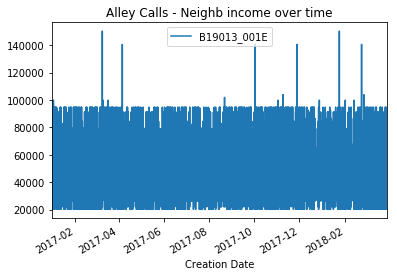

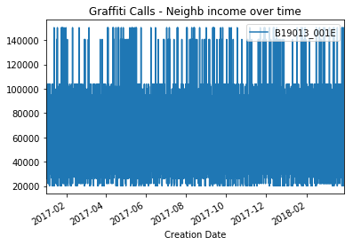

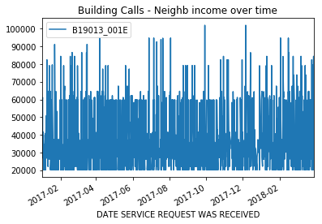

```python
alley_acs.plot(x='Creation Date', y=INCOME, title="Alley Calls - Neighb income over time")
graffiti_acs.plot(x='Creation Date', y=INCOME, title="Graffiti Calls - Neighb income over time")
building_acs.plot(x='DATE SERVICE REQUEST WAS RECEIVED', y=INCOME, title='Building Calls - Neighb income over time')
plt.show()
```

```python
alley_owners = alley_acs[TENURE_OWNER].sum()
alley_renters = alley_acs[TENURE_RENTER].sum()

graffiti_owners = graffiti_acs[TENURE_OWNER].sum()
graffiti_renters = graffiti_acs[TENURE_RENTER].sum()

building_owners = building_acs[TENURE_OWNER].sum()
building_renters = building_acs[TENURE_RENTER].sum()

print("The ratio of renters to owners for Alley calls is {}".format(alley_renters/alley_owners))
print("The ratio of renters to owners for Building calls is {}".format(building_renters/building_owners))
print("The ratio of renters to owners for Graffiti calls is {}".format(graffiti_renters/graffiti_owners))
```

```
The ratio of renters to owners for Alley calls is 1.0344798692052568
The ratio of renters to owners for Building calls is 1.201859071464683
The ratio of renters to owners for Graffiti calls is 1.369274610503061
```

```python
alley_citizens = alley_acs[CITIZEN_USBORN].sum()
alley_non = alley_acs[CITIZEN_NON].sum()

graffiti_citizens = graffiti_acs[CITIZEN_USBORN].sum()
graffiti_non = graffiti_acs[CITIZEN_NON].sum()

building_citizens = building_acs[CITIZEN_USBORN].sum()
building_non = building_acs[CITIZEN_NON].sum()

print("The ratio of citizens:non for Alley calls is {}".format(alley_citizens/alley_non))
print("The ratio of citizens:non for Graffiti calls is {}".format(graffiti_citizens/graffiti_non))
print("The ratio of citizens:non for Building calls is {}".format(building_citizens/building_non))
```

```
The ratio of citizens:non for Alley calls is 5.955777849455747
The ratio of citizens:non for Graffiti calls is 4.080033628888703
The ratio of citizens:non for Building calls is 11.85071767451586
```

## Problem 3: 3600 W Roosevelt

### 3a.

Of the three types of requests you have data for, which request type is the most likely given the call came from 3600 W Roosevelt Ave? What are the probabilities for each type of request?

```python
CA = "Community Area"
CA_NORTH_LAWNDALE = 29

total_alley = len(alley)
total_graffiti = len(graffiti)
total_building = len(building)

NL_alley = len(alley[alley[CA] == CA_NORTH_LAWNDALE])
NL_graffiti = len(graffiti[graffiti[CA] == CA_NORTH_LAWNDALE])
NL_building = len(building[building[CA] == CA_NORTH_LAWNDALE])

pct_alley = NL_alley/total_alley
pct_graffiti = NL_graffiti/total_graffiti
pct_building = NL_building/total_building

print("{}% of Alley calls ({}) were from this address's Community Area.".format(pct_alley, NL_alley))
print("{}% of Graffiti calls ({}) were from this address's Community Area.".format(pct_graffiti, NL_graffiti))
print("{}% of Building calls ({}) were from this address's Community Area.".format(pct_building, NL_building))
```

```
0.016294559903947858% of Alley calls (570) were from this address's Community Area.
0.006219362532674187% of Graffiti calls (897) were from this address's Community Area.
0.02719572001783326% of Building calls (122) were from this address's Community Area.
```

Above, I've decided to group by granularity of Community Area. 3600 W Roosevelt Ave is drawn currently under Community Area 29. Using this detail, I've compiled the percentages for each of our three request types above. Although the highest proportion of calls from Community Area 29 are for Building calls, the highest total calls from Community Area 29 were for graffiti removal requests. Therefore, it is most likely that a call from this community area will be for a request for graffiti removal.

### 3b.

Let’s now assume that a call comes in about Graffiti Removal. Which is more likely – that the call came from Garfield Park or Uptown? How much more or less likely is it to be from Garfield Park vs Uptown?

```python
CA_EAST_GARFIELD=26
CA_WEST_GARFIELD=27
CA_UPTOWN=3

east = len(graffiti[graffiti[CA] == CA_EAST_GARFIELD ])
west = len(graffiti[graffiti[CA] == CA_WEST_GARFIELD])
uptown = len(graffiti[graffiti[CA] == CA_UPTOWN])

pct_garfield = (east + west)/total_graffiti*100
pct_uptown = uptown/total_graffiti*100

print("Garfield calls: {}%".format(pct_garfield))
print("Uptown calls: {}%".format(pct_uptown))
print("It is {}x more likely that the call was from Uptown than Garfield".format(pct_uptown/pct_garfield))
```

```
Garfield calls: 0.4291845493562232%
Uptown calls: 1.7042578712723693%
It is 3.97092084006462x more likely that the call was from Uptown than Garfield
```

Above, I used all 2017 data to determine the percentage of the total graffiti calls coming from East & West Garfield vs the percentage of calls oming from Uptown, based on the Community Area designations of each.

Given this data, roughly 0.43% of calls came from Garfield, whereas 1.7% of calls came from Uptown. Therefore, it is roughly four times more likely that a call for graffiti removal will come from Uptown rather than Garfield.

### 3c.

Now assume that you don’t have access to all the raw data and you know the following things:

- There are a total of 1000 calls, 600 from Garfield Park and 400 from Uptown.
- Of the 600 calls from Garfield Park, 100 of them are about Graffiti Removal. Of the 400 calls from Uptown, 160 are about Graffiti Removal.

If a call comes about Graffiti Removal, how much more/less likely is it that the call came from Garfield Park versus Uptown?

```python
total_calls = 1000
garfield_total_calls = 600
garfield_graffiti_calls = 100
uptown_total_calls = 400
uptown_graffiti_calls = 160

# Given the call is graffiti removal related, what is the likelihood it is from Garfield Park?
total_graffiti_calls = garfield_graffiti_calls + uptown_graffiti_calls

pct_graffiti_garfield = 100*garfield_graffiti_calls/total_graffiti_calls
pct_graffiti_uptown = 100*uptown_graffiti_calls/total_graffiti_calls

graffiti_ratio = pct_graffiti_uptown/pct_graffiti_garfield

print("% of graffiti-related calls from Garfield: {}%".format(pct_graffiti_garfield))
print("% of graffiti-related calls from Uptown {}%".format(pct_graffiti_uptown))
print("It is {}x more likely that the call was from Uptown than Garfield".format(pct_graffiti_uptown/pct_graffiti_garfield))
```

```
% of graffiti-related calls from Garfield: 38.46153846153846%
% of graffiti-related calls from Uptown 61.53846153846154%
It is 1.6x more likely that the call was from Uptown than Garfield
```

Above, using the given data from the problem, we must take the conditional expectation for each neighborhood based on the condition that the call is graffiti-related. Given the call is graffiti-related, there are a total of 100+160=260 calls among the two neighborhoods. Roughly 38% of those calls are from Garfield, and 62% are from Uptown. Therefore it is 1.6 times as likely that the call was from Uptown, rather than Garfield, based on the aggregate data given.